# P2_Entrega Final - Estadística II

Authors

Adrian Urbina Mendoza

Luciana Yangali Cáceres

Jorge Leon Villarreyes

Valentina Alvarez Beraun

Mateo Rodríguez Ramos

# Tema del Proyecto

Relación entre Salud Mental Digital y Hábitos de universitarios entre 16 y 29 años de edad, matriculados en universidades públicas o privadas durante el semestre 2025-1.

# Introducción y Relevancia

Hoy en día, el uso de redes sociales se ha consolidado como una práctica esencial en la vida universitaria, pues contribuye a la interacción social y al bienestar psicológico de los estudiantes *(Valerio Ureña & Serna Valdivi, 2018).* Este uso se incrementa año tras año, lo que genera múltiples interrogantes sobre su impacto en el estilo y la calidad de vida de los estudiantes. En este contexto, resulta relevante contrastar lo señalado en la investigación de *Younes et al. (2016)*, el cual encontró que “la adicción a Internet se asocia significativamente con la presencia de insomnio, ansiedad, depresión, estrés y baja autoestima en estudiantes universitarios”

Además, investigaciones internacionales han evidenciado que el uso excesivo de redes sociales y otras plataformas digitales puede asociarse a mayores niveles de ansiedad, estrés y dificultades en el descanso *(Twenge, 2019; Orben & Przybylski, 2019).* Sin embargo, en el contexto peruano aún existe un vacío en la información respecto a cómo estos hábitos digitales influyen en el desempeño académico y en la calidad de vida de los universitarios. Por ello, el presente estudio tiene como objetivo analizar esta relación, con el fin de plantear iniciativas que apoyen el bienestar de los estudiantes y que sirvan para prevenir problemas de salud mental dentro del entorno académico.

# Objetivos del Estudio

1. **Identificar los patrones de uso de redes sociales y hábitos de vida** de los estudiantes universitarios de 16 a 29 años, matriculados en universidades públicas y privadas durante el semestre 2025-1.
2. **Comparar y analizar el impacto del uso de redes sociales** en el rendimiento académico, salud mental y calidad de sueño entre estudiantes de universidades públicas y privadas.
3. **Evaluar la relación entre el tiempo dedicado a redes sociales** y variables de bienestar estudiantil (promedio académico, horas de sueño, actividad física y satisfacción personal), mediante análisis estadístico inferencial.
4. **Concientizar sobre el impacto del uso excesivo de redes sociales** en la salud mental digital de los universitarios peruanos.
5. **Aplicar los conocimientos del curso de Estadística II** para abordar una problemática social contemporánea, mediante pruebas de hipótesis, regresión y diseño experimental.

# Proveniencia de Datos

Para el presente proyecto se decidió trabajar con una base de datos previamente recolectada durante el ciclo académico 2025-1, a través de un trabajo de campo basado en encuestas aplicadas a estudiantes universitarios de 16 a 29 años, matriculados en universidades públicas y privadas.

El uso de esta base resulta pertinente, ya que abarca un ciclo académico completo, lo que permite observar de manera más clara la relación entre salud mental digital y hábitos de los universitarios en un período determinado. La base de datos incluye un número suficiente de observaciones y se encuentra en formato digital, lo que facilita su acceso, análisis y posterior procesamiento estadístico.

De acuerdo con los objetivos del curso, este proyecto nos permitirá desarrollar competencias en la gestión, análisis y modelamiento estadístico de datos reales, vinculando los contenidos teóricos con una problemática social de gran relevancia.

# Tecnologías y uso en el mundo real

En el contexto actual, el análisis de comportamiento digital y salud mental se ha convertido en un área de interés tanto para la industria tecnológica como para el ámbito de la salud pública. Diversas organizaciones y plataformas utilizan tecnologías modernas para estudiar y monitorear el bienestar digital de los usuarios.

## Herramientas y Tecnologías Aplicadas

### 1. Análisis de Comportamiento Digital

- **Screen Time Analytics**: Plataformas como iOS Screen Time y Android Digital Wellbeing implementan sistemas de monitoreo de uso de aplicaciones, permitiendo a los usuarios visualizar patrones de consumo digital y establecer límites de tiempo *(Apple Inc., 2024; Google, 2024)*.
- **Social Media Analytics**: Herramientas como Meta Business Suite, TikTok Analytics e Instagram Insights utilizan algoritmos de machine learning para analizar patrones de engagement, tiempo de uso y comportamiento de usuarios, proporcionando métricas detalladas sobre interacciones digitales *(Meta Platforms, 2024)*.

### 2. Aplicaciones en Salud Mental Digital

- **Aplicaciones de Bienestar**: Plataformas como Calm, Headspace y aplicaciones universitarias especializadas implementan sistemas de tracking del bienestar estudiantil mediante cuestionarios estandarizados, ejercicios de mindfulness y análisis de comportamiento digital *(Huberty et al., 2019)*.
- **Sistemas de Detección Temprana**: Instituciones educativas de vanguardia implementan sistemas de *early warning* que correlacionan el uso de plataformas de aprendizaje digital (LMS) con indicadores académicos y de salud mental, permitiendo intervenciones oportunas *(Pistilli & Arnold, 2010)*.

### 3. Herramientas de Ingeniería de Datos y Análisis

- **Big Data Analytics**: Uso de lenguajes de programación como **Python** (con bibliotecas como pandas, numpy, scikit-learn) y **R** (tidyverse, ggplot2) para el análisis estadístico de grandes volúmenes de datos de comportamiento digital.
- **Visualización de Datos**: Herramientas empresariales como Tableau y Power BI, junto con bibliotecas especializadas como ggplot2 y Plotly, permiten representar patrones de uso, correlaciones y tendencias de manera interactiva.
- **Machine Learning**: Modelos predictivos basados en Random Forest, Redes Neuronales y Análisis de Regresión para identificar usuarios en riesgo de adicción digital, problemas de salud mental o bajo rendimiento académico.

### 4. Aplicación en Negocios y Marketing Digital

- **Customer Engagement Analysis**: Empresas tecnológicas analizan patrones de uso para optimizar experiencias de usuario, personalizar contenido y fomentar un engagement responsable que considere el bienestar digital de los usuarios.
- **EdTech Platforms**: Plataformas educativas como Canvas, Moodle, Blackboard y Google Classroom integran analytics de comportamiento estudiantil para mejorar resultados académicos, identificar estudiantes en riesgo y personalizar experiencias de aprendizaje.

## Relevancia en el Contexto Peruano

En Perú, el tema de salud mental digital está cobrando relevancia institucional:

- El **Ministerio de Salud (MINSA)** ha implementado el programa “Salud Mental en Universidades” que incluye componentes de monitoreo del bienestar estudiantil y uso de tecnologías digitales *(MINSA, 2023)*.
- Universidades peruanas como UTEC, PUCP y UPC están implementando sistemas de *learning analytics* y programas de bienestar estudiantil que consideran el impacto del uso de tecnologías digitales en el rendimiento académico y salud mental.
- El sector privado, a través de startups peruanas de *healthtech* y *edtech*, está desarrollando soluciones tecnológicas para el monitoreo del bienestar digital y la prevención de problemas de salud mental en población joven.

# Variables

Se han podido identificar las siguientes variables en la base de datos escogida:

Tabla 1: Variables del estudio con descripción y tipo de dato

| N° | Variable | Descripción | Tipo de Dato | Categoría |  |  |  |
| --- | --- | --- | --- | --- | --- | --- | --- |
| 1 | edad | ¿Cuál es tu edad? | Cuantitativo discreto | Demográfica |  |  |  |
| 2 | sexo | ¿Cuál es tu sexo? | Cualitativo nominal |  |  |  |  |
| 3 | tipo_universidad | ¿Estás en una universidad privada o pública? | Cualitativo nominal |  |  |  |  |
| 4 | prom_estudio_dia | ¿Cuántas horas en promedio al día estudias? | Cuantitativo continuo |  | Académica |  |  |
| 5 | prom_dia_whatsapp | ¿Cuántas horas al día en promedio usas WhatsApp? | Cualitativo ordinal |  | Redes Sociales |  |  |
| 6 | prom_dia_instagram | ¿Cuántas horas al día en promedio usas Instagram? | Cualitativo ordinal |  |  |  |  |
| 7 | prom_dia_tiktok | ¿Cuántas horas al día en promedio usas TikTok? | Cualitativo ordinal |  |  |  |  |
| 8 | prom_dia_linkedin | ¿Cuántas horas al día en promedio usas LinkedIn? | Cualitativo ordinal |  |  |  |  |
| 9 | prom_dia_x | ¿Cuántas horas al día en promedio usas X (Twitter)? | Cualitativo ordinal |  |  |  |  |
| 10 | ciclo | ¿En qué ciclo te encuentras? | Cualitativo ordinal | Académica |  |  |  |
| 11 | prom_ciclo_pasado | ¿Cuál fue tu promedio ponderado el ciclo pasado? | Cuantitativo continuo |  |  |  |  |
| 12 | total_cursos_actuales | ¿Cuántas asignaturas cursas actualmente? | Cuantitativo discreto |  |  |  |  |
| 13 | actividad_extracurricular_actual | ¿En qué tipo de actividades extracurriculares participas actualmente? | Cualitativo nominal |  |  | Actividades |  |
| 14 | horas_ejercicio_semanal | ¿Cuántas horas a la semana haces ejercicio físico? | Cuantitativo discreto |  |  | Salud |  |
| 15 | horas_sueño_xnoche | ¿Cuántas horas duermes aproximadamente por noche? | Cuantitativo discreto |  |  |  |  |
| 16 | red_mas_usada | ¿Qué plataforma de red social es la que más usas? | Cualitativo nominal | Redes Sociales |  |  |  |
| 17 | tiempo_max_sin_redes_dia | ¿Cuál es el tiempo máximo que puedes estar sin revisar tus redes sociales? | Cuantitativo discreto |  |  |  |  |
| 18 | notificaciones_estudio_diario | ¿Cuántas veces al día revisas tu teléfono por notificaciones de redes sociales mientras estudias? | Cuantitativo discreto |  |  |  |  |
| 19 | dias_redes_antes_de_dormir | ¿Cuántos días a la semana sueles usar redes sociales antes de dormir? | Cuantitativo discreto |  |  |  |  |
| 20 | tipo_contenido_redes_sociales | ¿Qué tipo de contenido consumes principalmente en redes sociales? | Cualitativo nominal |  |  |  |  |
| 21 | satisfaccion_interaccion_social_presencial | ¿Qué tan satisfecho estás con tu interacción social presencial con amigos o compañeros en tu centro de estudio y/o trabajo? | Cualitativo ordinal |  |  |  | Social |
| 22 | afecta_concentracion_rendimiento | ¿Cuanto consideras que el uso de redes sociales afecta tu capacidad de concentración y rendimiento académico? | Cualitativo ordinal |  |  | Académica |  |
| 23 | impacto_redes_actividades_extracurriculares | ¿Cuanto consideras que el uso de redes sociales te motiva o desmotiva a participar en actividades extracurriculares? | Cualitativo ordinal |  | Actividades |  |  |
| 24 | impacto_redes_salud_mental | ¿Qué tanto sientes que el uso excesivo de redes sociales puede afectar tu salud mental (autoestima, etc.)? | Cualitativo ordinal |  | Salud Mental |  |  |
| 25 | momento_uso_redes_sociales | ¿En qué momento del día usas más las redes sociales? | Cualitativo nominal | Redes Sociales |  |  |  |
| 26 | uso_redes_academicas | ¿Utilizas las redes sociales para acceder a información académica? | Cualitativo nominal |  |  |  |  |
| 27 | satisfaccion_rendimiento_academico | ¿Qué tan satisfecho(a) estás con tu rendimiento académico actual? | Cualitativo ordinal |  | Académica |  |  |
| 28 | interaccion_persona_amigos_redes | ¿Con cuántos de los amigos que conociste a través de redes sociales interactúas también en persona? | Cuantitativo discreto | Social |  |  |  |
| 29 | frecuencia_descubrimiento_actividades_redes | ¿Con qué frecuencia descubres actividades extracurriculares a través de redes sociales? | Cualitativo ordinal | Actividades |  |  |  |

# Configuración Inicial

```r
# Cargar librerías necesarias
library(readr)
library(dplyr)
library(ggplot2)
library(knitr)
library(kableExtra)
library(car)        # Para VIF y pruebas de supuestos
library(lmtest)     # Para pruebas adicionales de regresión
library(tidyr)
library(corrplot)   # Para matriz de correlaciones
library(gridExtra)  # Para organizar múltiples gráficos
library(BSDA)
```

# Factibilidad

El proyecto es factible ya que:

- Se cuenta con una base de datos existente y accesible, recolectada en el marco del ciclo 2025-1.
- La base contiene más de 1000 observaciones.
- Las variables están clasificadas en distintos tipos:
  - **Categóricas nominales:** Universidad (pública/privada), sexo, uso de redes sociales e impacto en sus actividades diarias.
  - **Categóricas ordinales:** Satisfacción con el rendimiento académico, efecto en horario de sueño y promedio de uso por red social.
  - **Cuantitativas continuas:** Promedio de nota del ciclo anterior, promedio de horas de estudio
  - **Cuantitativas discretas:** Horas de sueño por noche, horas de ejercicio semanal y edad.

Gracias a estas características, se puede realizar un análisis completo y cumplir con los requerimientos metodológicos del curso. En futuras entregas se adjuntará la base de datos en formato CSV (UTF-8).

| Variable | Total | Completos | Valores NA | % Completos |
| --- | --- | --- | --- | --- |
| edad | 1419 | 1419 | 0 | 100.00 |
| sexo | 1419 | 1419 | 0 | 100.00 |
| tipo_universidad | 1419 | 1419 | 0 | 100.00 |
| prom_estudio_dia | 1419 | 1417 | 2 | 99.86 |
| prom_dia_whatsapp | 1419 | 1396 | 23 | 98.38 |
| prom_ciclo_pasado | 1419 | 1418 | 1 | 99.93 |
| ciclo | 1419 | 1419 | 0 | 100.00 |
| total_cursos_actuales | 1419 | 1419 | 0 | 100.00 |
| actividad_extracurricular_actual | 1419 | 1419 | 0 | 100.00 |
| horas_ejercicio_semanal | 1419 | 1419 | 0 | 100.00 |
| horas_sueño_xnoche | 1419 | 1419 | 0 | 100.00 |
| red_mas_usada | 1419 | 1419 | 0 | 100.00 |
| tiempo_max_sin_redes_dia | 1419 | 1419 | 0 | 100.00 |
| notificaciones_estudio_diario | 1419 | 1413 | 6 | 99.58 |
| dias_redes_antes_de_dormir | 1419 | 1419 | 0 | 100.00 |
| tipo_contenido_redes_sociales | 1419 | 1418 | 1 | 99.93 |
| satisfaccion_interaccion_social_presencial | 1419 | 1419 | 0 | 100.00 |
| afecta_concentracion_rendimiento | 1419 | 1418 | 1 | 99.93 |
| impacto_redes_actividades_extracurriculares | 1419 | 1418 | 1 | 99.93 |
| impacto_redes_salud_mental | 1419 | 1418 | 1 | 99.93 |
| momento_uso_redes_sociales | 1419 | 1415 | 4 | 99.72 |
| uso_redes_academicas | 1419 | 1414 | 5 | 99.65 |
| satisfaccion_rendimiento_academico | 1419 | 1414 | 5 | 99.65 |
| interaccion_persona_amigos_redes | 1419 | 1412 | 7 | 99.51 |
| frecuencia_descubrimiento_actividades_redes | 1419 | 1411 | 8 | 99.44 |
| prom_dia_instagram | 1419 | 1403 | 16 | 98.87 |
| prom_dia_tiktok | 1419 | 1402 | 17 | 98.80 |
| prom_dia_linkedin | 1419 | 1398 | 21 | 98.52 |
| prom_dia_x | 1419 | 1403 | 16 | 98.87 |

# Obtención de la muestra

## Tamaño de muestra para nuestra data

Primero, hallamos el tamaño total de nuestra data, para darnos una idea de con qué estamos trabajando.

```r
nrow(df_na)
```

```
[1] 1419
```

### Variables cuantitativas

Nuestra población es de 1419 personas, lo cual es bastante. Entonces, sería muy útil sacar una muestra para realizar estimaciones sobre la media o la varianza.

Por ello, hallaremos el tamaño de muestra óptimo para nuestras variables cuantitativas:

Procedemos a ver cuáles son nuestras variables cuantitativas de nuestro dataset.

```
Variables cuantitativas encontradas:
```

```
 [1] "edad"                             "prom_estudio_dia"
 [3] "prom_ciclo_pasado"                "total_cursos_actuales"
 [5] "horas_ejercicio_semanal"          "horas_sueño_xnoche"
 [7] "tiempo_max_sin_redes_dia"         "notificaciones_estudio_diario"
 [9] "dias_redes_antes_de_dormir"       "interaccion_persona_amigos_redes"
```

En clase, se nos fue proporcionado un código que nos sacaba un tamaño de muestra en base a la desviación estándar, el nivel de confianza y la toleracia (hiperparámetro).

Nuestro nivel de confianza es de 96%. Pero tenemos que hallar las desviaciones estándar de nuestros atributos cuantitativos. Por ello, hallamos las desviaciones

```
Desviaciones estándar:
```

```
                            edad                 prom_estudio_dia
                        2.342371                         2.611903
               prom_ciclo_pasado            total_cursos_actuales
                        5.043512                         1.361606
         horas_ejercicio_semanal               horas_sueño_xnoche
                        3.952805                         1.206720
        tiempo_max_sin_redes_dia    notificaciones_estudio_diario
                        5.067710                        13.291672
      dias_redes_antes_de_dormir interaccion_persona_amigos_redes
                        1.923690                         8.900324
```

Ahora calculamos los tamaños de muestra para nuestro atributos:

```
[1] 334.123
```

Tamaño de muestra para:

Para hallar el tamaño de muestra, aplicamos:

$$n=\max_{1\leq i\leq M} n_{i}$$

### Variables Cualitativas

Para variables cualitativas, necesitamos saber las proporciones de cada valor que puede tomar cada atributo cuanlitativo.

```
Variables cualitativas encontradas:
```

```
 [1] "sexo"
 [2] "tipo_universidad"
 [3] "prom_dia_whatsapp"
 [4] "ciclo"
 [5] "actividad_extracurricular_actual"
 [6] "red_mas_usada"
 [7] "tipo_contenido_redes_sociales"
 [8] "satisfaccion_interaccion_social_presencial"
 [9] "afecta_concentracion_rendimiento"
[10] "impacto_redes_actividades_extracurriculares"
[11] "impacto_redes_salud_mental"
[12] "momento_uso_redes_sociales"
[13] "uso_redes_academicas"
[14] "satisfaccion_rendimiento_academico"
[15] "frecuencia_descubrimiento_actividades_redes"
[16] "prom_dia_instagram"
[17] "prom_dia_tiktok"
[18] "prom_dia_linkedin"
[19] "prom_dia_x"
```

```
Proporciones para: prom_dia_x
```

```
0 horas (no lo uso)     Entre 1-3 horas     Entre 3-6 horas     Entre 6-9 horas
        0.712758375         0.195295795         0.056307912         0.026372060
   Entre 9-12 horas
        0.009265859
```

Observación: En nuestro dataset, hay algunas variables cualitativas que tienen más de dos valores posibles, por lo que no se puede usar directamente el código proporcionado por el profesor. Por ende, se hará uso de la proporción que sea más cercana a 0.5, o la más conservadora.

```
[1] 345.4175
```

Tamaños de muestra cualitativa para:

1. “sexo”: 275.393 (Tol: 0.060)
2. “tipo_universidad”: 315.2984 (Tol: 0.050)
3. “prom_dia_whatsapp”: 292.5329 (Tol: 0.060)
4. “ciclo”: 255.4911 (Tol: 0.050)
5. “actividad_extracurricular_actual”: 292.8445 (Tol: 0.060)
6. “red_mas_usada”: 291.3654 (Tol: 0.060)
7. “tipo_contenido_redes_sociales”: 354.1118 (Tol: 0.050)
8. “satisfaccion_interaccion_social_presencial”: 334.1264 (Tol: 0.055)
9. “afecta_concentracion_rendimiento”: 365.5023 (Tol: 0.050)
10. “impacto_redes_actividades_extracurriculares”: 292.3487 (Tol: 0.060)
11. “impacto_redes_salud_mental”: 260.1794 (Tol: 0.060)
12. “momento_uso_redes_sociales”: 287.3459 (Tol: 0.060)
13. “uso_redes_academicas”: 317.4495 (Tol: 0.040)
14. “satisfaccion_rendimiento_academico”: 285.5579 (Tol: 0.060)
15. “frecuencia_descubrimiento_actividades_redes”: 269.4867 (Tol: 0.060)
16. “prom_dia_instagram”: 289.3336 (Tol: 0.060)
17. “prom_dia_tiktok”: 284.3253 (Tol: 0.060)
18. “prom_dia_linkedin”: 322.582 (Tol: 0.050)
19. “prom_dia_x”: 345.4175 (Tol: 0.050)

Volvemos a usar:

$$n=\max_{1\leq i\leq M} n_{i}$$

Entonces, nuestro tamaño de muestra máximo cualitativo sería 365.5023 que pasa a ser 366.

## Tamaño final de la muestra:

Para elegir el tamaño de muestra final aplicamos: máx(max_cuantitativo, max_cualitativo)

Entonces, sacamos la muestra y la guardamos en un csv, para los futuros ejercicios.

```r
# Para que los resultados sean reproducibles
set.seed(123)  # Cualquier número
max_size = 366
muestra <- df_na[sample(nrow(df_na), max_size), ]
```

```r
muestra
```

```
# A tibble: 366 × 29
    edad sexo      tipo_universidad prom_estudio_dia prom_dia_whatsapp
   <int> <fct>     <fct>                       <dbl> <ord>
 1    18 Femenino  Privada                       3   Entre 1-3 horas
 2    21 Femenino  Privada                       4   Entre 3-6 horas
 3    24 Masculino Pública                       1.5 Entre 1-3 horas
 4    23 Femenino  Privada                       3.5 <NA>
 5    18 Femenino  Privada                      10   Entre 9-12 horas
 6    18 Masculino Pública                       1   Entre 3-6 horas
 7    23 Masculino Privada                       4   Entre 3-6 horas
 8    22 Femenino  Pública                       5   Entre 1-3 horas
 9    18 Masculino Privada                       4   Entre 1-3 horas
10    21 Masculino Privada                       3   Entre 1-3 horas
# ℹ 356 more rows
# ℹ 24 more variables: prom_ciclo_pasado <dbl>, ciclo <ord>,
#   total_cursos_actuales <int>, actividad_extracurricular_actual <fct>,
#   horas_ejercicio_semanal <int>, horas_sueño_xnoche <int>,
#   red_mas_usada <fct>, tiempo_max_sin_redes_dia <int>,
#   notificaciones_estudio_diario <int>, dias_redes_antes_de_dormir <int>,
#   tipo_contenido_redes_sociales <fct>, …
```

# Carga y Preparación de Datos

```r
# Leer la muestra de datos
DF <- read_csv("muestra.csv", col_types = cols(.default = "c"))

# Convertir tipos de datos según especificaciones del proyecto
DF <- DF %>%
  mutate(
    # Cuantitativas discretas
    edad = as.integer(edad),
    total_cursos_actuales = as.integer(total_cursos_actuales),
    horas_ejercicio_semanal = as.integer(horas_ejercicio_semanal),
    horas_sueño_xnoche = as.integer(horas_sueño_xnoche),
    tiempo_max_sin_redes_dia = as.integer(tiempo_max_sin_redes_dia),
    notificaciones_estudio_diario = as.integer(notificaciones_estudio_diario),
    dias_redes_antes_de_dormir = as.integer(dias_redes_antes_de_dormir),
    interaccion_persona_amigos_redes = as.integer(interaccion_persona_amigos_redes),

    # Cuantitativas continuas
    prom_estudio_dia = as.numeric(prom_estudio_dia),
    prom_ciclo_pasado = as.numeric(prom_ciclo_pasado),

    # Cualitativas nominales
    sexo = factor(sexo, levels = c("Femenino", "Masculino")),
    tipo_universidad = factor(tipo_universidad, levels = c("Privada", "Pública")),
    actividad_extracurricular_actual = factor(actividad_extracurricular_actual),
    red_mas_usada = factor(red_mas_usada),
    tipo_contenido_redes_sociales = factor(tipo_contenido_redes_sociales,
                                           levels = c("Académico", "Entretenimiento", "Noticias", "Socializar")),
    uso_redes_academicas = factor(uso_redes_academicas, levels = c("No", "Sí")),
    impacto_redes_actividades_extracurriculares = factor(impacto_redes_actividades_extracurriculares,
                                                         levels = c("Desmotiva", "Motiva", "No tiene efecto")),
    momento_uso_redes_sociales = factor(momento_uso_redes_sociales),

    # Cualitativas ordinales (escalas 1-5)
    afecta_concentracion_rendimiento = factor(afecta_concentracion_rendimiento,
                                              levels = c("1", "2", "3", "4", "5"), ordered = TRUE),
    impacto_redes_salud_mental = factor(impacto_redes_salud_mental,
                                        levels = c("1", "2", "3", "4", "5"), ordered = TRUE),
    satisfaccion_interaccion_social_presencial = factor(satisfaccion_interaccion_social_presencial,
                                                        levels = c("1", "2", "3", "4", "5"), ordered = TRUE),
    satisfaccion_rendimiento_academico = factor(satisfaccion_rendimiento_academico,
                                                levels = c("1", "2", "3", "4", "5"), ordered = TRUE),
    frecuencia_descubrimiento_actividades_redes = factor(frecuencia_descubrimiento_actividades_redes,
                                                         levels = c("1", "2", "3", "4", "5"), ordered = TRUE),
    ciclo = factor(as.character(ciclo), levels = as.character(1:10), ordered = TRUE)
  )
```

```
Dimensiones del dataset: 366 filas x 29 columnas
```

```
Total de observaciones válidas para análisis: 364
```

# Analísis de las distribuciones

### Caso 1

Efecto del uso nocturno de redes sociales en las horas de sueño de estudiantes universitarios

#### Contexto

El incremento del uso nocturno de redes sociales entre los jóvenes universitarios se ha asociado con una reducción en las horas de descanso, afectando su concentración y bienestar general.

Se desea analizar si los estudiantes que usan redes sociales más de 5 noches por semana duermen significativamente menos horas que aquellos que las usan menos de 3 noches por semana. Este análisis contribuye al objetivo de comparar el impacto del uso de redes sociales en el rendimiento académico y la calidad del sueño de los universitarios.

#### Tipo de análisis y distribución utilizada:

El objetivo es comparar las medias de horas de sueño entre dos grupos independientes (A y B), definidos por su frecuencia de uso nocturno de redes sociales.

Por ello, se analizará la distribución muestral de la diferencia de medias, que nos permite inferir si la diferencia observada entre ambos grupos es estadísticamente significativa o podría deberse al azar.

Dado que ambas muestras superan los 30 elementos y se desconoce la distribución poblacional de las horas de sueño, se aplica el Teorema del Límite Central (TLC), que garantiza que la distribución muestral de las medias se aproxima a una distribución normal. La diferencia de medias muestrales se distribuye como:

$$\bar{X}_A - \bar{X}_B \sim N\left(
\mu_A - \mu_B,\;
\sqrt{\frac{\sigma_A^2}{n_A} + \frac{\sigma_B^2}{n_B}}
\right)$$

#### Variables utilizadas:

- `dias_redes_antes_de_dormir` : número de días por semana que el estudiante usa redes antes de dormir.
- `horas_sueño_xnoche` : promedio de horas dormidas por noche.

#### Grupos definidos:

- Grupo A: quienes usan redes ≤ 3 días por semana
- Grupo B: quienes usan redes ≥ 5 días por semana

```r
# Crear grupos
grupo_A <- DF %>% filter(dias_redes_antes_de_dormir <= 3)
grupo_B <- DF %>% filter(dias_redes_antes_de_dormir >= 5)
```

#### Estadísticos descriptivos:

Se necesitan los promedios, desviaciones estándar de `horas_sueño_xnoche` en cada grupo, y sus tamaños muestrales (`n`):

```r
# Estadísticos resumen
resumen = DF %>%
  mutate(grupo = case_when(
    dias_redes_antes_de_dormir <= 3 ~ "A_poco_uso",
    dias_redes_antes_de_dormir >= 5 ~ "B_alto_uso",
    TRUE ~ "intermedio"
  )) %>%
  filter(grupo != "intermedio") %>%
  group_by(grupo) %>%
  summarise(
    n = n(),
    media = mean(horas_sueño_xnoche, na.rm = TRUE),
    sd = sd(horas_sueño_xnoche, na.rm = TRUE)
  )

resumen
```

```
# A tibble: 2 × 4
  grupo          n media    sd
  <chr>      <int> <dbl> <dbl>
1 A_poco_uso    54  6.22  1.49
2 B_alto_uso   287  6.26  1.16
```

De aca se obtiene que:

- El grupo A cuenta con 54 registros, un $\overline{x}$ de 6,2222 y un $s$ de 1,4879
- El grupo B cuenta con 287 registros, un $\overline{x}$ de 6,2578 y un $s$ de 1,1631

Estos valores son nuestras estimaciones de los parámetros poblacionales.

#### Cálculos inferenciales:

- La diferencia de medias:

$$\bar{X}_A - \bar{X}_B$$

Esta cantidad representa cuánto difiere, en promedio, el número de horas de sueño entre los dos grupos.

- La desviación estándar de la diferencia:

$$\sigma_{\bar{X}_A - \bar{X}_B} = \sqrt{\frac{s_A^2}{n_A} + \frac{s_B^2}{n_B}}$$

donde:

1. $s_A, s_B$ son las desviaciones estándar muestrales de cada grupo,
2. $n_A,n_B$ son los tamaños de muestra
3. $\sigma_{\bar{X} _A - \bar{X}_B}$ mide la variabilidad esperada entre posibles diferencias de medias si se repite el muestreo muchas veces.
- Probabilidad de observar una diferencia igual o mayor a 0.5 horas:

Se utiliza la distribución normal estándar:

$$P(\bar{X}_A - \bar{X}_B \ge 0.5) = 1 - \Phi\left(
\frac{0.5 - (\bar{X}_A - \bar{X}_B)}{
\sigma_{\bar{X}_A - \bar{X}_B}
}
\right)$$

donde $\Phi(z)$ es la función de distribución acumulada de la normal estándar.

A continuación se calculan la diferencia de medias, su desviación estándar y la probabilidad de observar una diferencia de al menos 0.5 horas.

```r
# Extraer valores del resumen
muA = resumen$media[resumen$grupo == "A_poco_uso"]
muB = resumen$media[resumen$grupo == "B_alto_uso"]
sigmaA = resumen$sd[resumen$grupo == "A_poco_uso"]
sigmaB = resumen$sd[resumen$grupo == "B_alto_uso"]
nA = resumen$n[resumen$grupo == "A_poco_uso"]
nB = resumen$n[resumen$grupo == "B_alto_uso"]

# Media y desviación de la diferencia
media_dif = muA - muB
desv_dif = sqrt((sigmaA^2 / nA) + (sigmaB^2 / nB))

# Probabilidad de que la diferencia sea >= 0.5 h
probabilidad = pnorm(0.5, mean = media_dif, sd = desv_dif, lower.tail = FALSE)

media_dif; desv_dif; probabilidad
```

```
[1] -0.0356175
```

```
[1] 0.2138008
```

```
[1] 0.006118811
```

Se obtuvo que:

- La diferencia promedio real entre los grupos (en horas):

  $$|\bar{X}_A - \bar{X}_B|=0.0356$$
- La desviación estándar de la diferencia muestral:

  $$\sigma_{\bar{X}_A - \bar{X}_B} = 0.2138$$
- La probabilidad de una diferencia mayor o igual a 0.5 horas:

  $$P(\bar{X}_A - \bar{X}_B \ge 0.5) = 0.0061$$

#### Visualización de la distribución muestral:

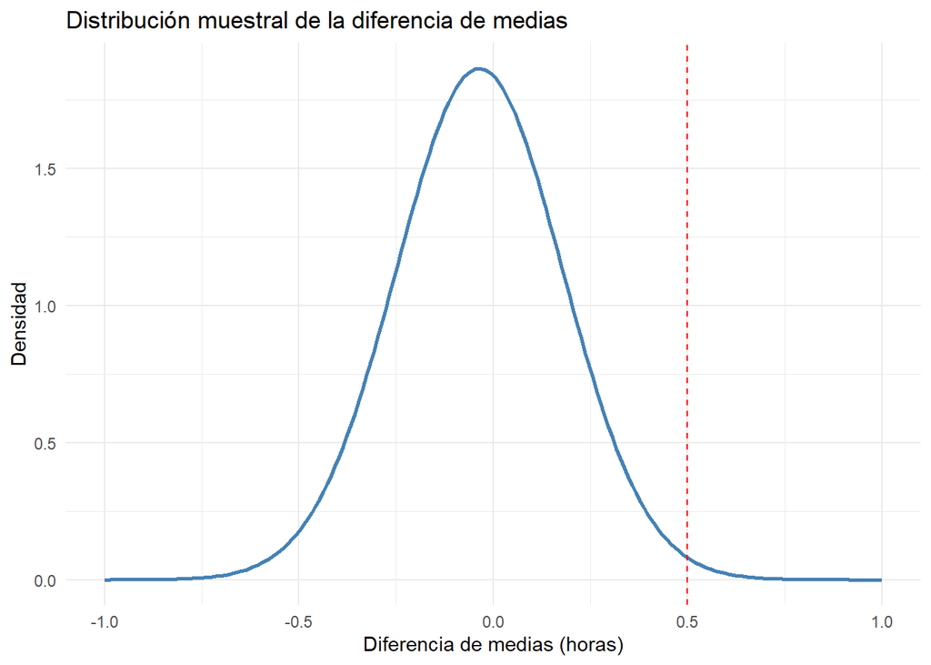

El gráfico muestra que la distribución muestral de la diferencia de medias está centrada cerca de cero, lo que indica una diferencia promedio mínima en las horas de sueño entre los grupos. La línea roja (diferencia de 0.5 horas) cae en la cola derecha de la distribución, donde la probabilidad es muy baja, evidenciando que sería poco común observar una diferencia tan grande por azar. Esto respalda la conclusión de que el uso nocturno frecuente de redes sociales no se asocia significativamente con una menor cantidad de sueño en esta muestra.

#### Interpretación de los resultados:

Los resultados muestran que la diferencia promedio real en las horas de sueño entre ambos grupos es muy pequeña (≈ 0.036 horas). La desviación estándar muestral de la diferencia es 0.214, lo que sugiere una baja variabilidad entre posibles diferencias obtenidas en muestras similares. La probabilidad de observar una diferencia igual o mayor a 0.5 horas fue 0.0061, lo que indica que es muy poco probable que ocurra por azar.

Por tanto, el uso frecuente de redes antes de dormir no parece asociarse con una reducción significativa en las horas de sueño dentro de esta muestra.

Sin embargo, es importante considerar que pueden existir otros factores (como el nivel de estrés o el tipo de contenido consumido) que moderen esta relación.

En conclusión, los resultados no respaldan la hipótesis de una diferencia significativa en las horas de sueño asociada al uso frecuente de redes sociales antes de dormir.

## Caso 2

#### Contexto

Se desea evaluar la variabilidad en el tiempo de estudio diario entre estudiantes universitarios de diferente sexo que utilizan redes sociales de manera intensa, para este caso será enfocada en Instagram. Se tienen 2 poblaciones, una de sexo femenino y otra de sexo masculino. El primer grupo son los estudiantes de sexo masculino que usan Instagram más de 3 horas al día. El otro grupo son los estudiantes de sexo femenino que usan Instagram más de 3 horas al día. ¿Cuál es la probabilidad de que la varianza del promedio de horas de estudio diarias de los estudiantes masculinos que usan Instagram más de 3 horas al día supere a la varianza de las estudiantes femeninas que usan Instagram más de 3 horas al día en un 40% de su valor?

#### Variables a utilizar:

- `sexo` : Determina el sexo del estudiante.
- `prom_estudio_dia` : promedio de horas de estudio en el día.

#### Solución

Primero, tenemos que hallar las dos poblaciones: Masculino y Femenino.

```r
# Población 1: Masculino
datos_masculino <- DF %>%
  filter(sexo == "Masculino") %>%
  filter(!is.na(prom_estudio_dia))

# Población 2: Femenino
datos_femenino <- DF %>%
  filter(sexo == "Femenino") %>%
  filter(!is.na(prom_estudio_dia))
```

Ahora podemos sacar las varianzas de nuestras poblaciones:

```r
varF <- var(datos_femenino$prom_estudio_dia)
varF
```

```
[1] 6.244763
```

```r
varM <- var(datos_masculino$prom_estudio_dia)
varM
```

```
[1] 7.593624
```

Ahora hallamos el tamaño de nuestras muestras, para masculino como para femenino:

```
=== DATOS FILTRADOS ===
```

```
Total de estudiantes masculinos que usan Instagram >3 horas (nm): 42
```

```
=== DATOS FILTRADOS ===
```

```
Total de estudiantes femeninos que usan Instagram >3 horas (nf): 34
```

Podemos visualizar estas dos muestras de la siguiente manera:

[figure not shown]

Los resultados muestran que la varianza del tiempo de estudio en hombres (11.834) es aproximadamente 2.37 veces mayor que en mujeres (4.99), superando ampliamente el umbral del 40% establecido en la pregunta de investigación. Esta diferencia sustancial indica que los estudiantes masculinos presentan una mayor inconsistencia en sus hábitos de estudio, con algunos estudiando muy poco y otros dedicando hasta 20 horas diarias, mientras que las estudiantes femeninas mantienen patrones más regulares y concentrados alrededor de 4 horas diarias.

Esto implica que el uso intensivo de Instagram afecta de manera diferenciada la consistencia de los hábitos de estudio según el género: las mujeres demuestran mayor autorregulación y estabilidad en sus rutinas académicas a pesar del uso intensivo de redes sociales, mientras que los hombres exhiben comportamientos más polarizados, con mayor dispersión entre aquellos que compensan el tiempo en redes estudiando más y aquellos que se distraen considerablemente. Este hallazgo resulta relevante para comprender cómo las redes sociales impactan diferencialmente el rendimiento académico según características demográficas de los estudiantes universitarios.

A continuación, calculamos la probabilidad:

$$P\left(S_M^2 \geq S_F^2 \cdot 1{,}40\right) \
=P\left(\frac{S_M^2}{S_F^2} \cdot \frac{\sigma_M^2}{\sigma_F^2} \geq 1{,}40 \frac{\sigma_M^2}{\sigma_F^2}\right) \
=P\left(F(nm-1, nf-1) \geq 1{,}40\frac{\sigma_M^2}{\sigma_F^2}\right)$$

Siendo:

- nm: Tamaño de muestra de masculino
- nf: tamaño de muestra de femenino.

```r
pf(1.40*varM/varF,41,33, lower.tail = FALSE)
```

```
[1] 0.05915765
```

#### Conclusiones

Se halló que la probabilidad es de aproximadamente 6%. Esto significa que, si repetimos el muestreo muchas veces, solo en aproximadamente 6 de cada 100 muestras observaríamos que la varianza masculina supera en 40% o más a la femenina. Este resultado sugiere que aunque es poco probable que esta diferencia de varianzas ocurra por azar en muestras aleatorias, en los datos observados el fenómeno está claramente presente.

## Caso 3

Se desea analizar si los estudiantes que realizan más horas de ejercicio físico a la semana presentan, en promedio, un rendimiento académico previo (medido como el prom_ciclo_pasado) al menos 0.5 puntos superior al de aquellos que realizan menos actividad física.

Para ello, se utilizarán las siguientes variables del conjunto de datos:

- *prom_ciclo_pasado:* variable continua, que representa el promedio académico obtenido por el estudiante en el ciclo anterior.
- *horas_ejercicio_semanal:* variable discreta, que indica el número de horas dedicadas al ejercicio físico por semana. Se utilizará para dividir la muestra en dos grupos:
  - *Alto ejercicio:* estudiantes que realizan 5 horas o más por semana.
  - *Bajo ejercicio:* estudiantes que realizan menos de 5 horas por semana.
- *prom_estudio_dia:* variable continua, que representa las horas promedio de estudio diario. Esta variable podrá considerarse más adelante como covariable para controlar su posible efecto en el rendimiento.

El análisis se basará en el uso de distribuciones muestrales de la diferencia de medias y la aproximación normal proporcionada por el Teorema Central del Límite (TCL).

#### Concepto Estadistico

Aplicaremos una distribución muestral de la diferencia de medias. Si se extraen muestras independientes de dos poblaciones, la diferencia muestral de medias

$$\overline{X_1} - \overline{X_2}$$

se distribuye aproximadamente como una normal:

$$\overline{X_1} - \overline{X_2} ~ N( \mu_1 - \mu_2, \sqrt{\frac{S^2_1}{n_1}+\frac{S^2_2}{n_2}}$$

Usaremos esta distribución para hallar la probabilidad de que la diferencia sea >= 0.5.

#### Resolución práctica

Transformamos la variable para poder evaluarla por intervalos:

```r
DF_S3 <- DF %>%
  mutate(
    grupo_ejercicio = ifelse(horas_ejercicio_semanal >= 5,
                            "Alto ejercicio (≥5h)",
                            "Bajo ejercicio (<5h)")
  )
```

Vemos la frecuencia y proporción de cada clase:

```r
tabla_freq <- table(DF_S3$grupo_ejercicio)
cat("\nDistribución de estudiantes por grupo:\n")
```

```
Distribución de estudiantes por grupo:
```

```r
print(tabla_freq)
```

```
Alto ejercicio (≥5h) Bajo ejercicio (<5h)
                 121                  245
```

```r
cat("\nPorcentajes:\n")
```

```
Porcentajes:
```

```r
print(prop.table(tabla_freq) * 100)
```

```
Alto ejercicio (≥5h) Bajo ejercicio (<5h)
            33.06011             66.93989
```

Vemos los datos estádisticos

```
# A tibble: 2 × 11
  grupo_ejercicio          n media mediana desv_std varianza minimo maximo    Q1
  <chr>                <int> <dbl>   <dbl>    <dbl>    <dbl>  <dbl>  <dbl> <dbl>
1 Alto ejercicio (≥5h)   121  13.2    14.3     4.80     23.1      0     20    13
2 Bajo ejercicio (<5h)   245  12.7    14       5.18     26.9      0     20    12
# ℹ 2 more variables: Q3 <dbl>, error_std <dbl>
```

Revisamos las distribuciones mediante histogramas:

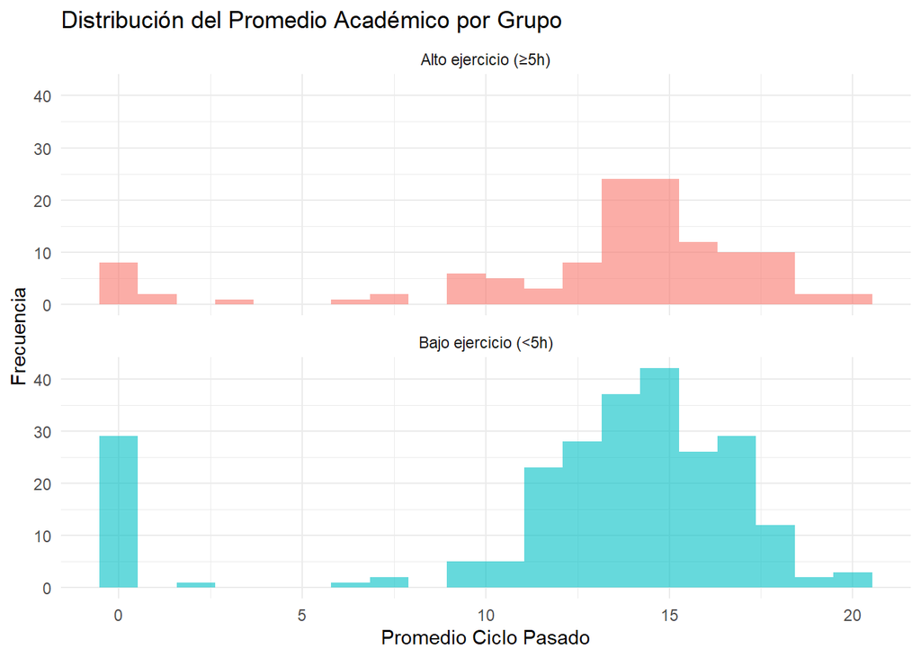

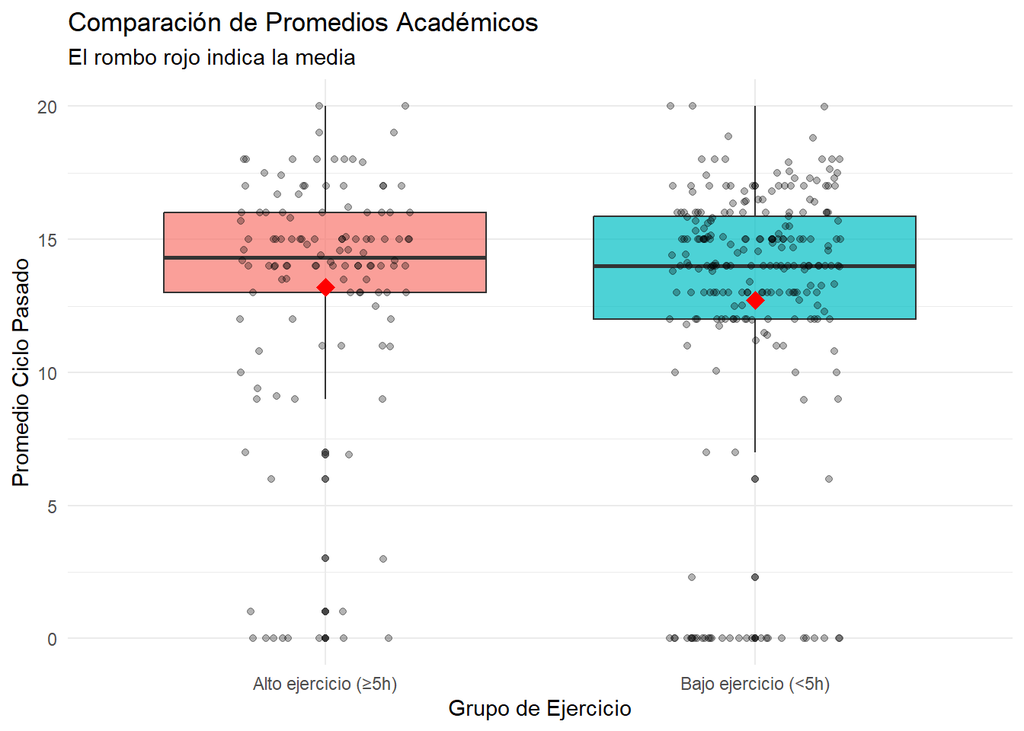

Vamos a separar los grupos por las clases en que clasificamos la variable de promedio de horas de ejercicio. De esta manera calcularemos sus estadísticos mustrales.

```
--- Estadísticos Muestrales ---
```

```
Grupo Alto Ejercicio: n₁ = 121, x̄₁ = 13.2061, s₁ = 4.8043
```

```
Grupo Bajo Ejercicio: n₂ = 245, x̄₂ = 12.7040, s₂ = 5.1849
```

```
Diferencia observada: x̄₁ - x̄₂ = 0.5021
```

```
[1] 0.5481586
```

```r
# Estadístico Z
z_calculado <- (diferencia_obs - delta0) / ee_diferencia
cat(sprintf("\nEstadístico de prueba: Z = %.4f\n", z_calculado))
```

```
Estadístico de prueba: Z = -0.0000
```

```r
# Valor crítico y p-valor
alpha <- 0.05
z_critico <- qnorm(1 - alpha)
p_valor <- 1 - pnorm(z_calculado)
cat(sprintf("Valor crítico (α=0.05): Z_crítico = %.4f\n", z_critico))
```

```
Valor crítico (α=0.05): Z_crítico = 1.6449
```

```r
cat(sprintf("P-valor: %.6f\n", p_valor))
```

```
P-valor: 0.500012
```

#### Conclusiones

No existe evidencia estadística suficiente para afirmar que los estudiantes con alto nivel de ejercicio físico tienen, en promedio, un rendimiento académico previo **al menos 0.5 puntos superior** al de los estudiantes con bajo nivel de ejercicio.

En otras palabras, aunque el grupo con mayor actividad física podría mostrar una leve diferencia positiva, **esta no es estadísticamente significativa** según los datos disponibles.

# Analísis de los Intervalos de Confianza

## Caso 1: IC para una proporción

### Planteamiento

Estimar, con **96% de confianza**, la **proporción de estudiantes** que **utilizan redes sociales para acceder a información académica** en la población objetivo.

### Población y variable

- **Población:** estudiantes universitarios considerados en el estudio.
- **Variable:** `uso_redes_academicas` (Sí/No). Éxito = “Sí”.

### Método de estimación (IC 96%)

A partir de la muestra de tamaño
$$n$$
, se calcula la proporción muestral
$$\hat p = x/n$$
y el **intervalo de confianza (IC) de Wald**:

$$\hat p \pm z_{0.98}\,\sqrt{\frac{\hat p(1-\hat p)}{n}}.$$

donde
$$z_{0.98} \approx 2.0537$$
corresponde a un nivel de confianza del 96% donde α=0.04

### Cálculo en R

```r
# IC 96% para una proporción (Wald) usando la muestra en DF
nc <- 0.96
alpha <- 1 - nc
z_critico <- qnorm(1 - alpha/2)

x <- sum(DF$uso_redes_academicas == "Sí", na.rm = TRUE)  # éxitos
n <- sum(!is.na(DF$uso_redes_academicas))                # n válido
p <- x / n

error_estandar <- sqrt(p * (1 - p) / n)
margen_de_error <- z_critico * error_estandar

extremo_inferior <- p - margen_de_error
extremo_superior <- p + margen_de_error

# Imprimir resultados:
print(paste("significación:",alpha))
```

```
[1] "significación: 0.04"
```

```r
print(paste("Error estándar:", error_estandar))
```

```
[1] "Error estándar: 0.0168741873612284"
```

```r
print(paste("Z crítico:", z_critico))
```

```
[1] "Z crítico: 2.05374891063182"
```

```r
print(paste("margen de error o Tolerancia:", margen_de_error))
```

```
[1] "margen de error o Tolerancia: 0.03465534391092"
```

```r
print(paste("IC: (",round(extremo_inferior, 4),";", round(extremo_superior, 4),")"))
```

```
[1] "IC: ( 0.8475 ; 0.9168 )"
```

Con un nivel de significación α=0.04 (confianza del 96%), estimamos la proporción de estudiantes que utilizan redes sociales con fines académicos. El intervalo de confianza obtenido es **[0.8475, 0.9168]**, lo que indica que, en la población de interés, **entre 84.75% y 91.68%** de los estudiantes harían uso académico de las redes.

**Para el proyecto**, este resultado respalda que el **uso académico de redes es alto** en la población estudiantil.

## Caso 2: Diferencia de medias: rendimiento (pública vs privada)

### Planteamiento

Tratamos de comparar el impacto del uso de redes sociales en el rendimiento académico entre estudiantes de universidades públicas y privadas.  
¿Difieren las medias de `prom_ciclo_pasado` entre los tipos de universidad (Pública vs Privada)?

```r
# Paso 1: Filtrado de datos válidos
# Se consideran estudiantes entre 16 y 29 años con promedio registrado
DFx <- subset(DF, is.na(edad) | (edad >= 16 & edad <= 29))
DFx <- subset(DFx, !is.na(prom_ciclo_pasado) & tipo_universidad %in% c("Privada", "Pública"))

# Paso 2: Separación por tipo de universidad
Priv <- subset(DFx, tipo_universidad == "Privada")
Publ <- subset(DFx, tipo_universidad == "Pública")
```

### Estadísticas muestrales

$$\text{Para cada grupo } k \in \{1=\text{Privada},\,2=\text{Pública}\}:
\quad n_k \ (\text{tamaño}),\quad \bar x_k \ (\text{media}),\quad s_k \ (\text{desv. est.}).$$

$$\begin{aligned}
\textbf{Privada:}&\quad n_1 = 267,\quad s_1 = 4.221017,\quad \bar x_1 = 13.83307,\\[4pt]
\textbf{Pública:}&\quad n_2 = 98,\quad s_2 = 6.145050,\quad \bar x_2 = 10.24265.
\end{aligned}$$

```r
# Paso 3: Cálculo de medias y desviaciones estándar
mean(Priv$prom_ciclo_pasado)   # Media Privada
```

```
[1] 13.83307
```

```r
sd(Priv$prom_ciclo_pasado)     # Desviación estándar Privada
```

```
[1] 4.221017
```

```r
mean(Publ$prom_ciclo_pasado)   # Media Pública
```

```
[1] 10.24265
```

```r
sd(Publ$prom_ciclo_pasado)     # Desviación estándar Pública
```

```
[1] 6.14505
```

Complementaremos el análisis con el fundamento teórico detrás del código en R:

### Diferencia de medias y error estándar

$$\hat\Delta=\bar x_1-\bar x_2,\qquad
SE=\sqrt{\frac{s_1^2}{n_1}+\frac{s_2^2}{n_2}}.$$

$$\hat\Delta = 13.83307-10.24265=3.59042,\qquad
SE=\sqrt{\frac{4.221017^2}{267}+\frac{6.145050^2}{98}}\approx 0.67235.$$

### Grados de libertad:

$$\nu \approx
\frac{\left(\frac{s_1^2}{n_1}+\frac{s_2^2}{n_2}\right)^2}{
\frac{\left(\frac{s_1^2}{n_1}\right)^2}{n_1-1}+
\frac{\left(\frac{s_2^2}{n_2}\right)^2}{n_2-1}
}
\approx 132.06.$$

### Valor crítico (96%)

$$t^\* = t_{0.98,\ \nu\approx132} \approx 2.07.$$

```r
# --- Paso 4: Evaluación de igualdad de varianzas ---
# Cálculo del intervalo de confianza para la razón de varianzas (Privada/Pública)
var1 <- sd(Priv$prom_ciclo_pasado)^2   # Varianza Privada
var2 <- sd(Publ$prom_ciclo_pasado)^2   # Varianza Pública
nc <- 0.96
n1 <- length(Priv$prom_ciclo_pasado)
n2 <- length(Publ$prom_ciclo_pasado)
alpha <- 1 - nc

VC1 <- qf(alpha/2, n2-1, n1-1)
VC2 <- qf(1 - alpha/2, n2-1, n1-1)

extremo_inf <- (var1/var2) * VC1
extremo_sup <- (var1/var2) * VC2

var1
```

```
[1] 17.81699
```

```r
var2
```

```
[1] 37.76164
```

```r
n1
```

```
[1] 267
```

```r
n2
```

```
[1] 98
```

```r
VC1
```

```
[1] 0.6977753
```

```r
VC2
```

```
[1] 1.394468
```

```r
extremo_inf
```

```
[1] 0.3292297
```

```r
extremo_sup
```

```
[1] 0.6579486
```

### Intervalo de confianza al 96%

$$\hat\Delta \pm t^\* SE
= 3.59042 \pm 2.07\times 0.67235
\Rightarrow (\,2.196,\ 4.985\,).$$

```r
# Paso 5: Prueba t para la diferencia de medias (Welch)
t.test(Priv$prom_ciclo_pasado, Publ$prom_ciclo_pasado,
       var.equal = FALSE, conf.level = 0.96)
```

```
    Welch Two Sample t-test

data:  Priv$prom_ciclo_pasado and Publ$prom_ciclo_pasado
t = 5.3401, df = 132.06, p-value = 3.939e-07
alternative hypothesis: true difference in means is not equal to 0
96 percent confidence interval:
 2.195810 4.985026
sample estimates:
mean of x mean of y
 13.83307  10.24265
```

Con un nivel de confianza del 96%, se encontró que los estudiantes de universidades privadas presentan un promedio de rendimiento entre **2.20 y 4.99 puntos superior** al de los estudiantes de universidades públicas. Dado que el intervalo de confianza no incluye el valor cero y el p-valor es extremadamente bajo (p < 0.001), se concluye que **existe una diferencia significativa** en el rendimiento académico promedio según el tipo de universidad.

## Caso 3: Diferencia de proporciones: Impacto en salud mental según uso nocturno de redes sociales

### Planteamiento

En esta situación se busca analizar si los universitarios peruanos de 16 a 29 años que usan redes sociales con mayor frecuencia antes de dormir (≥5 noches por semana) presentan mayor proporción de alto impacto en salud mental (niveles 4 y 5 en la escala) que quienes no lo hacen tan seguido.

### Fundamento teórico

El intervalo de confianza para la **diferencia de proporciones** se utiliza cuando se desea comparar la proporción de éxito en dos grupos independientes.  
Sea:

$$\hat{p}_1 = \frac{x_1}{n_1}, \qquad \hat{p}_2 = \frac{x_2}{n_2}$$

donde:

$$(x_1), (x_2): \text{ número de individuos que presentan la característica de interés (éxitos).} \\
(n_1), (n_2): \text{ tamaños muestrales de cada grupo.}$$

El estimador puntual de la diferencia es:

$$\hat{p}_1 - \hat{p}_2$$

y su error estándar se calcula como:

$$SE = \sqrt{\frac{\hat{p}_1(1-\hat{p}_1)}{n_1} + \frac{\hat{p}_2(1-\hat{p}_2)}{n_2}}$$

El intervalo de confianza al nivel (1 - alpha) es entonces:

$$(\hat{p}_1 - \hat{p}_2) \pm z_{1-\alpha/2} \times SE$$

Si el intervalo **incluye el valor cero**, no se puede afirmar que exista una diferencia estadísticamente significativa entre las proporciones de ambos grupos.

### Desarrollo y código

```r
DF16_29 <- DF |>
  filter(as.integer(edad) >= 16, as.integer(edad) <= 29)

# Definir alto uso nocturno y alto impacto (codificación numérica 1–5)
DFy <- DF16_29 |>
  mutate(
    alto_noct    = dias_redes_antes_de_dormir >= 5,
    alto_impacto = as.numeric(impacto_redes_salud_mental) >= 4
  ) |>
  filter(!is.na(alto_noct), !is.na(alto_impacto))

# Conteos por grupo
n1 <- sum(DFy$alto_noct)
x1 <- sum(DFy$alto_noct & DFy$alto_impacto)
n2 <- sum(!DFy$alto_noct)
x2 <- sum(!DFy$alto_noct & DFy$alto_impacto)

# Proporciones muestrales
p1 <- x1/n1
p2 <- x2/n2

# Nivel de confianza (96%)
nc <- 0.96
alpha <- 1 - nc
z_crítico <- qnorm(1 - alpha/2, 0, 1)

# Cálculo del intervalo de confianza (Wald)
error_estandar <- sqrt(p1*(1-p1)/n1 + p2*(1-p2)/n2)
margen_de_error <- z_crítico * error_estandar
extremo_inferior <- (p1 - p2) - margen_de_error
extremo_superior <- (p1 - p2) + margen_de_error

print(paste("IC: (", extremo_inferior, ";", extremo_superior, ")"))
```

```
[1] "IC: ( -0.0719308708301256 ; 0.180959230553144 )"
```

Los resultados obtenidos con la muestra fueron los siguientes:

$$\text{Tamaño del grupo 1 (uso nocturno alto): } 287$$

$$\text{Tamaño del grupo 2 (uso nocturno bajo): } 79 \\$$

$$\text{Proporciones muestrales: } (p_1 = 0.4216), (p_2 = 0.3671) \\$$
$$\text{Diferencia: } (\hat{p}_1 - \hat{p}_2 = 0.0545) \\$$
$$\text{Error estándar: } 0.0616 \\$$
$$\text{Margen de error: } 0.1264 \\$$
$$\text{IC 96%: } [-0.0719, 0.1810]$$

```r
# Reproducción del intervalo con los valores hallados
p1 <- 0.4216; p2 <- 0.3671; n1 <- 287; n2 <- 79
z <- qnorm(0.98)
se <- sqrt(p1*(1-p1)/n1 + p2*(1-p2)/n2)
li <- (p1-p2) - z*se; ls <- (p1-p2) + z*se
c(LI = li, LS = ls)
```

```
         LI          LS
-0.07194566  0.18094566
```

Con un **nivel de confianza del 96 %**, la diferencia de proporciones de estudiantes con **alto impacto en salud mental** entre quienes usan redes **≥ 5 noches por semana** y quienes lo hacen con menor frecuencia se encuentra entre **−7.2 % y +18.1 %**.

Dado que el intervalo **incluye 0**, **no se evidencia una diferencia estadísticamente significativa** entre ambos grupos.  
Sin embargo, el valor puntual (≈ 5.4 % más alto en los de uso nocturno intenso) sugiere una **tendencia leve** hacia mayor afectación entre quienes utilizan redes sociales con mayor frecuencia antes de dormir.

# Análisis con Pruebas de Hipotesis

## Caso 1: Comparación base del rendimiento académico entre universidades

La SUNEDU está estudiando los hábitos de estudio de los universitarios para comprender qué factores podrían influir en el rendimiento académico. Para evitar sesgos, solo se consideran **estudiantes que ya tienen al menos un ciclo cursado**, es decir, aquellos cuyo **promedio del ciclo anterior es mayor que 0**. Los estudiantes recién ingresados no se incluyen porque no cuentan con historial académico.

En este estudio, se desea comparar a dos grupos:

- Estudiantes de universidades privadas
- Estudiantes de universidades públicas

El objetivo es evaluar si **la proporción de estudiantes con promedio aprobatorio (≥ 13)** es similar en ambos tipos de universidad.  
La dirección académica desea comprobar, con evidencia estadística, si ambas proporciones pueden considerarse iguales.

### Planteamiento de la hipótesis

Las proporciones a evaluar son:

$$\pi_1 :\text{proporción de alumnos con promedio aprobatorio } (\geq 13) \text{en universidades privadas}\\$$

$$\pi_2 : \text{proporción de alumnos con promedio aprobatorio } (\geq 13) \text{en universidades publicas}\\$$

Por lo cual nuestras hipótesis sería referentes a la igualdad de las proporciones:

$$H_{o}:\text{No hay diferencia en la proporción de alumnos aprobados en ambas universidades} \\$$

$$H_{a}:\text{Sí hay diferencia en la proporción de alumnos aprobados en ambas universidades}$$

De otra manera:

$$H_o: \pi_1 = \pi_2\\$$

$$H_a: \pi_2 \neq \pi_2$$

Asumimos un 4% de significación.

### Resolución del caso

Vamos a calcular las proporciones del dataset original de datos:

```r
datos = DF %>%
  mutate(prom_ciclo_pasado = as.numeric(prom_ciclo_pasado)) %>% #Convertir texto a número
  filter(prom_ciclo_pasado > 0) %>%#Filtro alumnos con al menos 1 ciclo
  mutate(aprobado = ifelse(prom_ciclo_pasado >= 13, 1, 0))#

#estudiantes de privada y que hayan aprobado
n1 = sum(datos$tipo_universidad == "Privada")
x1 = sum(datos$tipo_universidad == "Privada" & datos$aprobado == 1)

#estudiantes de pública y que hayan aprobado
n2 = sum(datos$tipo_universidad == "Pública")
x2 = sum(datos$tipo_universidad == "Pública" & datos$aprobado == 1)

#proporcion de aprobados/total estudiantes privada
p1= x1/n1

#proporcion de aprobados/total estudiantes privada
p2 = x2/n2

#calculando proporcion ponderada
pp= (x1+x2)/(n1+n2)

# Cálculo del Estadístico Z
Zo = (p1-p2) / sqrt(pp * (1-pp) * (1/n1 + 1/n2))

# Imprimimos los resultados
print(paste("tamaño muestral A (Privada) =", n1))
```

```
[1] "tamaño muestral A (Privada) = 250"
```

```r
print(paste("tamaño muestral B (Pública) =", n2))
```

```
[1] "tamaño muestral B (Pública) = 78"
```

```r
print(paste("proporción muestral A =", round(p1, 4)))
```

```
[1] "proporción muestral A = 0.876"
```

```r
print(paste("proporción muestral B =", round(p2, 4)))
```

```
[1] "proporción muestral B = 0.5769"
```

```r
print(paste("Proporción ponderada =", round(pp, 4)))
```

```
[1] "Proporción ponderada = 0.8049"
```

```r
print(paste("El estadístico de prueba Zo es", round(Zo, 4)))
```

```
[1] "El estadístico de prueba Zo es 5.819"
```

Se tiene que calcular el valor crítico, es decir, el número (Z) que delimita la región de rechazo. Se calculará con la normal estándar.

```r
alfa = 0.04
# Valor crítico izquierdo
VC1 = qnorm(alfa/2, 0, 1)
print(paste("Valor Crítico Inferior:", VC1))
```

```
[1] "Valor Crítico Inferior: -2.05374891063182"
```

```r
# Valor crítico derecho
VC2 = qnorm(1 - alfa/2, 0, 1)
print(paste("Valor Crítico Superior:", VC2))
```

```
[1] "Valor Crítico Superior: 2.05374891063182"
```

Como $Z_o = 5.819$, es mayor que $VC_2 = 2.05$, por lo que cae en la región sombreada.

Por tanto, se rechaza $H_o$

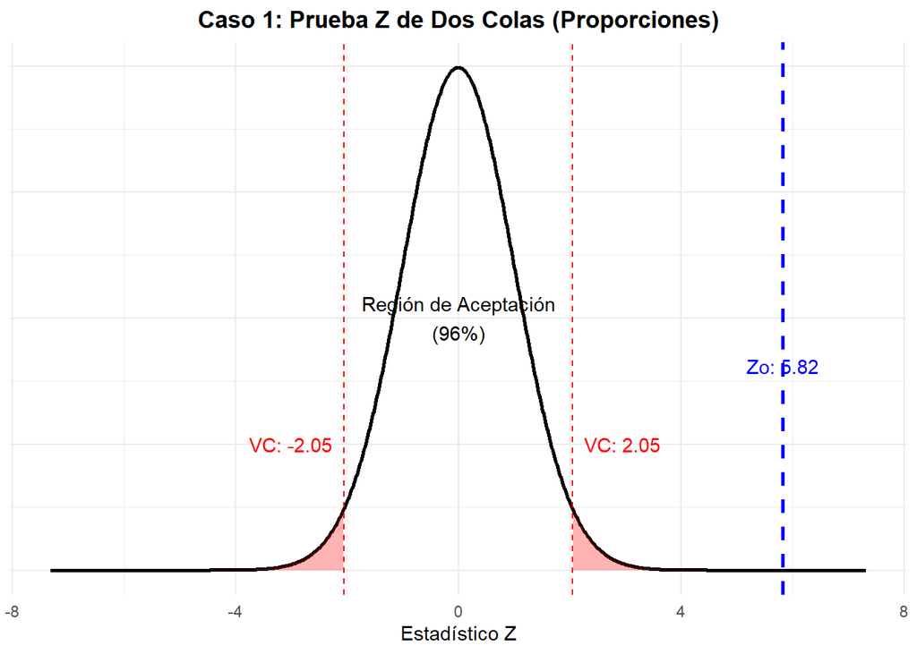

```r
rango_limite <- max(abs(c(VC1, VC2, Zo))) + 1.5
x_vals <- seq(-rango_limite, rango_limite, length.out = 1000)
df_norm <- data.frame(x = x_vals, y = dnorm(x_vals))

# Tema gráfico (estético)
tema_grafico <- theme_minimal() +
  theme(plot.title = element_text(hjust = 0.5, face = "bold"),
        axis.title.y = element_blank(),
        axis.text.y = element_blank(),
        axis.ticks.y = element_blank())

# --- Generación del Gráfico ---
grafico1 <- ggplot(df_norm, aes(x, y)) +
  geom_line(size = 1) +

  # 1. Áreas de rechazo (Rojo) usando tus variables VC1 y VC2
  geom_area(data = subset(df_norm, x <= VC1), fill = "red", alpha = 0.3) +
  geom_area(data = subset(df_norm, x >= VC2), fill = "red", alpha = 0.3) +

  # 2. Líneas de Valores Críticos (Rojo Discontinuo)
  geom_vline(xintercept = c(VC1, VC2), linetype = "dashed", color = "red") +

  # 3. Línea del Estadístico de Prueba Zo (Azul)
  geom_vline(xintercept = Zo, linetype = "dashed", color = "blue", size = 1) +

  # 4. Etiquetas de texto
  annotate("text", x = VC1 - 0.2, y = 0.1, label = paste("VC:", round(VC1, 2)), color = "red", hjust = 1) +
  annotate("text", x = VC2 + 0.2, y = 0.1, label = paste("VC:", round(VC2, 2)), color = "red", hjust = 0) +

  # Etiqueta para Zo (ajustada para que no se superponga si está lejos)
  annotate("text", x = Zo, y = 0.15, label = paste("Zo:", round(Zo, 2)), color = "blue", vjust = -0.5) +

  # Etiqueta central de aceptación (Calculada con tu 'alfa')
  annotate("text", x = 0, y = 0.2, label = paste("Región de Aceptación\n(", (1-alfa)*100, "%)", sep="")) +

  # Títulos
  labs(title = "Caso 1: Prueba Z de Dos Colas (Proporciones)", x = "Estadístico Z") +
  tema_grafico

# Mostrar Gráfico
print(grafico1)
```

### Conclusión

Dado que se rechaza $H_o$, existe evidencia estadística suficiente (con un 96% de confianza) para afirmar que sí hay diferencia en la proporción de aprobados entre universidades privadas y públicas. Los datos sugieren que el rendimiento no es igual en ambos grupos.

## Caso 2: Hábitos de sueño para el bienestar corporal

Una institución de bienestar universitario está evaluando los hábitos de sueño de los estudiantes, ya que en los últimos ciclos se han reportado incrementos en problemas de estrés, fatiga y bajo rendimiento académico.

Con el fin de analizar la situación, se toma una **muestra aleatoria de estudiantes que cursan el periodo académico 2025-1** , para asegurar que ya están adaptados a la carga académica. A cada estudiante se le registró cuántas **horas de sueño** tiene en promedio por noche.

Estudios previos sugieren que los estudiantes deberían dormir **al menos 7 horas diarias** para mantener un adecuado rendimiento y bienestar. Sin embargo, existe preocupación de que los estudiantes actuales estén durmiendo menos de esa cantidad.

Para este análisis contamos con una muestra, obtenida previamente, de 366 estudiantes.

### Planteamiento de la hipótesis

La media a evaluar es:

$$\mu = \text{horas de sueño diarios de los estudiantes durante este ciclo}$$

Por lo cual nuestras hipótesis sería:

$$H_o: \text{El promedio de las horas de sueño diario de los estudiantes es de almenos 7 horas} \\$$

$$H_a: \text{El promedio de las horas de sueño diario de los estudiantes es menor a 7 horas}$$

De otra manera:

$$H_o: \mu \ge 7 \\$$
$$H_a: \mu < 7$$

Asumimos un 4% de significación.

### Resolución del caso

Dado que el tamaño de la muestra es grande ($n>30$) se aplicó el Teorema del Límite Central para utilizar el estadístico $T$. Se estandarizó la media muestral calculando cuántas desviaciones estándar se alejan del valor hipotético de 7 horas.

```r
#limpiamos variable a utilizar, borramos NAs
datos_sueño = DF %>%
  mutate(horas_sueño_xnoche = as.numeric(horas_sueño_xnoche)) %>%
  filter(!is.na(horas_sueño_xnoche))

#estadisticas de variable
n = length(datos_sueño$horas_sueño_xnoche)
media_muestral = mean(datos_sueño$horas_sueño_xnoche)
desviacion_std = sd(datos_sueño$horas_sueño_xnoche)
mu_hipotesis = 7

#cálculo estadístico de prueba To

error_estandar = desviacion_std / sqrt(n)
To = (media_muestral - mu_hipotesis) / error_estandar

print(paste("Tamaño de muestra (n) =", n))
```

```
[1] "Tamaño de muestra (n) = 366"
```

```r
print(paste("Media muestral (x_barra) =", round(media_muestral, 4)))
```

```
[1] "Media muestral (x_barra) = 6.2814"
```

```r
print(paste("Desviación estándar (S) =", round(desviacion_std, 4)))
```

```
[1] "Desviación estándar (S) = 1.2073"
```

```r
print(paste("Estadístico de prueba (To) =", round(To, 4)))
```

```
[1] "Estadístico de prueba (To) = -11.3868"
```

Al plantearse una hipótesis alternativa de ‘menor que’ ($H_a: \mu < 7$ ), se utilizará una prueba de **cola izquierda**. Se calculará **Valor Crítico** correspondiente a un $\alpha=0.04$. Si el estadístico calculado ($Z_{calc}$) es menor que el valor crítico, se rechaza la hipótesis nula, confirmando que el promedio de sueño es inferior al recomendado.

```r
alfa = 0.04
VC = qnorm(alfa, 0, 1)

print(paste("Valor Crítico (VC) =", round(VC, 4)))
```

```
[1] "Valor Crítico (VC) = -1.7507"
```

Dado que $T_o = -11.39$ es mucho menor a $VC= -1.75$, cae en la región sombreada. Por tanto, se rechaza $H_o$.

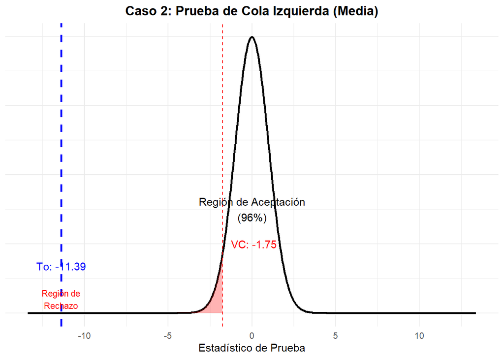

```r
rango_limite <- max(abs(c(VC, To))) + 2

# Creamos la secuencia de datos para la curva
x_vals <- seq(-rango_limite, rango_limite, length.out = 1000)
df_norm <- data.frame(x = x_vals, y = dnorm(x_vals))

tema_grafico <- theme_minimal() +
  theme(plot.title = element_text(hjust = 0.5, face = "bold"),
        axis.title.y = element_blank(),
        axis.text.y = element_blank(),
        axis.ticks.y = element_blank())

grafico2 <- ggplot(df_norm, aes(x, y)) +
  geom_line(size = 1) +

  # 1. Área de rechazo (Cola izquierda roja) usando tu variable VC
  geom_area(data = subset(df_norm, x <= VC), fill = "red", alpha = 0.3) +

  # 2. Línea del Valor Crítico (Rojo Discontinuo)
  geom_vline(xintercept = VC, linetype = "dashed", color = "red") +

  # 3. Línea del Estadístico de Prueba To (Azul)
  geom_vline(xintercept = To, linetype = "dashed", color = "blue", size = 1) +

  # 4. Etiquetas de texto
  # Etiqueta para el Valor Crítico
  annotate("text", x = VC + 0.5, y = 0.1, label = paste("VC:", round(VC, 2)), color = "red", hjust = 0) +

  # Etiqueta para el Estadístico To (ajustada para que no choque)
  annotate("text", x = To, y = 0.05, label = paste("To:", round(To, 2)), color = "blue", vjust = -1) +

  # Texto de regiones
  annotate("text", x = -rango_limite + 2, y = 0.02, label = "Región de\nRechazo", color = "red", size=3) +
  annotate("text", x = 0, y = 0.15, label = paste("Región de Aceptación\n(", (1-alfa)*100, "%)", sep="")) +

  # Títulos
  labs(title = "Caso 2: Prueba de Cola Izquierda (Media)", x = "Estadístico de Prueba") +
  tema_grafico

# Mostrar Gráfico 2
print(grafico2)
```

### Conclusión

Se concluye que existe evidencia suficiente (con un 96% de confianza) para afirmar que el promedio de horas de sueño de los estudiantes es **significativamente menor a 7 horas**. Esto valida la preocupación de la institución sobre el bienestar estudiantil.